# Vignobles MBV Quebec

Adriel M Sierra

2026-10-07

# **Grapevine Endosphytes & Grape trunk diseases (GTD)**

This reproducible quarto document contains the complete statistical analysis, machine learning models, and ecological assembly null modeling workflows for evaluating grapevine trunk disease (GTD) effects on endophyte tissue dynamics and microbiote dysbiosis across 50 cold-climate vineyards in Québec, Canada.

By integrating high-throughput amplicons sequencing (16S rRNA and ITS2) with qPCR detection of major fungal wood pathogens (*Eutypa lata* and *Diplodia seriata*), this project explores how tissue compartmentalization, management practices, and host microbiota composition are related to the emergence/occurence of grapevine trunk disease (GTDs) dieback.

### Library

R-packages use for the analyses

```r
#Library
library(microeco)
library(tidyverse)
#remotes::install_github("ChiLiubio/mecodev")
library(mecodev)
library(stringr)
library(ggpubr)
library(vegan)
library(rstatix)
#packages for building a map
# Install if you haven't already: install.packages(c("ggplot2", "raster", "geodata", "sf"))
library(ggplot2)
library(raster)
library(sf)
library(geodata)
#devtools::install_github("microsud/dysbiosisR")
library(dysbiosisR)

# packages used to build the quarto document
library(DT)
```

### Datasets

Complete and processed datasets are available as a microtable object.

```r
# bacteria endophyte
MBV16S_mt = readRDS("01_MBV16S_microtable_jan26.rds")
# fungal endophyte
MBVITS_mt = readRDS("01_MBVITS_microtable_jan26.rds")
```

Microtables with alpha- and beta-diversity estimates included

```r
MBV16S_mt_est <- readRDS("02_MBV16S_microtable_estimates_jan26.rds")
MBVITS_mt_est <- readRDS("02_MBVITS_microtable_estimates_jan26.rds")
MBV16S_alpha = readRDS("02_MBVBacterial_alphadiv.rds")
MBVITS_alpha = readRDS("02_MBVFungal_alphadiv.rds")
```

Dysbiosis score

```r
#datasets
dysbiosis_results_bacteria <- readRDS("03_DysbiosisBacteriaResults.rds")
dysbiosis_results_fungi <- readRDS("03_DysbiosisFungiResults.rds")
```

### Sampling design

A table include all the metadata associated for each sample.

Samples for Bacteria 16S amplicon-sequencing.

```r
DT::datatable(MBV16S_mt$sample_table)
```

|  | Rference.ASV | X | Echantillon | Annee.echantillonnage | Vignoble | Station.meteo | Type.de.regie | Cepage | Latitude.GPS | Longitude.GPS | Annee.de.plantation | Mode.de.conduite | Periode.de.taille | Tissu | Eutypa.lata | Diplodia.seriata | Copie.E.lata | Copie.D.seriata | Pathologie | Station.code | Station.name | Network | Latitude | Longitude | Elevation.meters | Timezone | Year | Max.Temp | Min.Temp | … |
| --- | --- | --- | --- | --- | --- | --- | --- | --- | --- | --- | --- | --- | --- | --- | --- | --- | --- | --- | --- | --- | --- | --- | --- | --- | --- | --- | --- | --- | --- | --- |
| 6A_b | 6A_b |  | 6A | 2021 | Domaine.Labranche | CWIT | Biologique | Frontenac | 45.306622 | -73.681197 | 2009 | Cordon.Royat | taille.finale.printemps | Cordon | 0 | 0 | 0 | 0 | Healthy | CWIT | Sainte.Clotilde | DEA | 45.166682 | -73.678318 | 52 | 6z | 2021 | 21.38937198 | 9.605339806 | … |
| 6C_b | 6C_b |  | 6C | 2021 | Domaine.Labranche | CWIT | Biologique | Frontenac | 45.306622 | -73.681197 | 2009 | Cordon.Royat | taille.finale.printemps | Courson.Sarment | 0 | 1 | 0 | 149 | Diplodia.seriata | CWIT | Sainte.Clotilde | DEA | 45.166682 | -73.678318 | 52 | 6z | 2021 | 21.38937198 | 9.605339806 | … |
| 7A_b | 7A_b |  | 7A | 2021 | Vignoble.Leblanc | CWBZ | Conventionnelle | Frontenac.gris | 45.13892746 | -74.35583496 | 2013 | Cordon.Royat | taille.finale.printemps | Cordon | 0 | 1 | 0 | 158 | Diplodia.seriata | CWBZ | Saint.Anicet | DEA | 45.1208 | -74.2895 | 48 | 6z | 2021 | 21.85211268 | 10.27981221 | … |
| 8A_b | 8A_b |  | 8A | 2021 | Vignoble.de.Pomone | CWBZ | Conventionnelle | Triomphe.d'Alsace | 45.29034424 | -74.20524596999999 | 2016 | Cordon.Royat | taille.finale.printemps | Cordon | 0 | 0 | 0 | 0 | Healthy | CWBZ | Saint.Anicet | DEA | 45.1208 | -74.2895 | 48 | 6z | 2021 | 21.85211268 | 10.27981221 | … |
| 8B_b | 8B_b |  | 8B | 2021 | Vignoble.de.Pomone | CWBZ | Conventionnelle | Triomphe.d'Alsace | 45.29034424 | -74.20524596999999 | 2016 | Cordon.Royat | taille.finale.printemps | Ecorce.Chancre | 0 | 1 | 0 | 2390 | Diplodia.seriata | CWBZ | Saint.Anicet | DEA | 45.1208 | -74.2895 | 48 | 6z | 2021 | 21.85211268 | 10.27981221 | … |
| 8C_b | 8C_b |  | 8C | 2021 | Vignoble.de.Pomone | CWBZ | Conventionnelle | Triomphe.d'Alsace | 45.29034424 | -74.20524596999999 | 2016 | Cordon.Royat | taille.finale.printemps | Courson.Sarment | 0 | 1 | 0 | 509 | Diplodia.seriata | CWBZ | Saint.Anicet | DEA | 45.1208 | -74.2895 | 48 | 6z | 2021 | 21.85211268 | 10.27981221 | … |
| 9B_b | 9B_b |  | 9B | 2021 | Domaine.du.Nival | CMSI | Biologique | Vidal | 45.869758 | -72.967141 | 2014 | Guyot | pre.taille.automne.taille.finale.printemps | Ecorce.Chancre | 0 | 0 | 0 | 0 | Healthy | CMSI | Saint.Germain.de.Grantham |  | 45.8253 | -72.537 | 85 | 6z | 2021 | 21.14413146 | 9.156807512 | … |
| 10B_b | 10B_b |  | 10B | 2021 | Vignoble.du.vent.maudit | CWEW | Biologique | St.Pepin | 46.1164856 | -73.22598267 | 2010 | Guyot | taille.finale.automne | Ecorce.Chancre | 0 | 0 | 0 | 0 | Healthy | CWEW | LAssomption | DEA | 45.8094 | -73.4348 | 20 | 6z | 2021 | 21.8943128 | 10.59336493 | … |
| 10C_b | 10C_b |  | 10C | 2021 | Vignoble.du.vent.maudit | CWEW | Biologique | St.Pepin | 46.1164856 | -73.22598267 | 2010 | Guyot | taille.finale.automne | Courson.Sarment | 1 | 0 | 1100 | 0 | Eutypa.lata | CWEW | LAssomption | DEA | 45.8094 | -73.4348 | 20 | 6z | 2021 | 21.8943128 | 10.59336493 | … |
| 11B_b | 11B_b |  | 11B | 2021 | CRAM | CWVQ | Conventionnelle | IRAC | 45.48667526 | -74.04681396 | 2015 | Gobelet | taille.finale.printemps | Ecorce.Chancre | 0 | 0 | 0 | 0 | Healthy | CWVQ | Sainte.Anne.de.Bellevue | DEA | 45.4272 | -73.9292 | 38 | 6z | 2021 | 21.54976526 | 11.25420561 | … |

[output cut: 177 more lines]

```r
DT::datatable(MBV16S_mt$sample_table)
```

|  | Rference.ASV | X | Echantillon | Annee.echantillonnage | Vignoble | Station.meteo | Type.de.regie | Cepage | Latitude.GPS | Longitude.GPS | Annee.de.plantation | Mode.de.conduite | Periode.de.taille | Tissu | Eutypa.lata | Diplodia.seriata | Copie.E.lata | Copie.D.seriata | Pathologie | Station.code | Station.name | Network | Latitude | Longitude | Elevation.meters | Timezone | Year | Max.Temp | Min.Temp | … |
| --- | --- | --- | --- | --- | --- | --- | --- | --- | --- | --- | --- | --- | --- | --- | --- | --- | --- | --- | --- | --- | --- | --- | --- | --- | --- | --- | --- | --- | --- | --- |
| 6A_b | 6A_b |  | 6A | 2021 | Domaine.Labranche | CWIT | Biologique | Frontenac | 45.306622 | -73.681197 | 2009 | Cordon.Royat | taille.finale.printemps | Cordon | 0 | 0 | 0 | 0 | Healthy | CWIT | Sainte.Clotilde | DEA | 45.166682 | -73.678318 | 52 | 6z | 2021 | 21.38937198 | 9.605339806 | … |
| 6C_b | 6C_b |  | 6C | 2021 | Domaine.Labranche | CWIT | Biologique | Frontenac | 45.306622 | -73.681197 | 2009 | Cordon.Royat | taille.finale.printemps | Courson.Sarment | 0 | 1 | 0 | 149 | Diplodia.seriata | CWIT | Sainte.Clotilde | DEA | 45.166682 | -73.678318 | 52 | 6z | 2021 | 21.38937198 | 9.605339806 | … |
| 7A_b | 7A_b |  | 7A | 2021 | Vignoble.Leblanc | CWBZ | Conventionnelle | Frontenac.gris | 45.13892746 | -74.35583496 | 2013 | Cordon.Royat | taille.finale.printemps | Cordon | 0 | 1 | 0 | 158 | Diplodia.seriata | CWBZ | Saint.Anicet | DEA | 45.1208 | -74.2895 | 48 | 6z | 2021 | 21.85211268 | 10.27981221 | … |
| 8A_b | 8A_b |  | 8A | 2021 | Vignoble.de.Pomone | CWBZ | Conventionnelle | Triomphe.d'Alsace | 45.29034424 | -74.20524596999999 | 2016 | Cordon.Royat | taille.finale.printemps | Cordon | 0 | 0 | 0 | 0 | Healthy | CWBZ | Saint.Anicet | DEA | 45.1208 | -74.2895 | 48 | 6z | 2021 | 21.85211268 | 10.27981221 | … |
| 8B_b | 8B_b |  | 8B | 2021 | Vignoble.de.Pomone | CWBZ | Conventionnelle | Triomphe.d'Alsace | 45.29034424 | -74.20524596999999 | 2016 | Cordon.Royat | taille.finale.printemps | Ecorce.Chancre | 0 | 1 | 0 | 2390 | Diplodia.seriata | CWBZ | Saint.Anicet | DEA | 45.1208 | -74.2895 | 48 | 6z | 2021 | 21.85211268 | 10.27981221 | … |
| 8C_b | 8C_b |  | 8C | 2021 | Vignoble.de.Pomone | CWBZ | Conventionnelle | Triomphe.d'Alsace | 45.29034424 | -74.20524596999999 | 2016 | Cordon.Royat | taille.finale.printemps | Courson.Sarment | 0 | 1 | 0 | 509 | Diplodia.seriata | CWBZ | Saint.Anicet | DEA | 45.1208 | -74.2895 | 48 | 6z | 2021 | 21.85211268 | 10.27981221 | … |
| 9B_b | 9B_b |  | 9B | 2021 | Domaine.du.Nival | CMSI | Biologique | Vidal | 45.869758 | -72.967141 | 2014 | Guyot | pre.taille.automne.taille.finale.printemps | Ecorce.Chancre | 0 | 0 | 0 | 0 | Healthy | CMSI | Saint.Germain.de.Grantham |  | 45.8253 | -72.537 | 85 | 6z | 2021 | 21.14413146 | 9.156807512 | … |
| 10B_b | 10B_b |  | 10B | 2021 | Vignoble.du.vent.maudit | CWEW | Biologique | St.Pepin | 46.1164856 | -73.22598267 | 2010 | Guyot | taille.finale.automne | Ecorce.Chancre | 0 | 0 | 0 | 0 | Healthy | CWEW | LAssomption | DEA | 45.8094 | -73.4348 | 20 | 6z | 2021 | 21.8943128 | 10.59336493 | … |
| 10C_b | 10C_b |  | 10C | 2021 | Vignoble.du.vent.maudit | CWEW | Biologique | St.Pepin | 46.1164856 | -73.22598267 | 2010 | Guyot | taille.finale.automne | Courson.Sarment | 1 | 0 | 1100 | 0 | Eutypa.lata | CWEW | LAssomption | DEA | 45.8094 | -73.4348 | 20 | 6z | 2021 | 21.8943128 | 10.59336493 | … |
| 11B_b | 11B_b |  | 11B | 2021 | CRAM | CWVQ | Conventionnelle | IRAC | 45.48667526 | -74.04681396 | 2015 | Gobelet | taille.finale.printemps | Ecorce.Chancre | 0 | 0 | 0 | 0 | Healthy | CWVQ | Sainte.Anne.de.Bellevue | DEA | 45.4272 | -73.9292 | 38 | 6z | 2021 | 21.54976526 | 11.25420561 | … |

[output cut: 177 more lines]

#### Map of vineyards analyzed across Québec

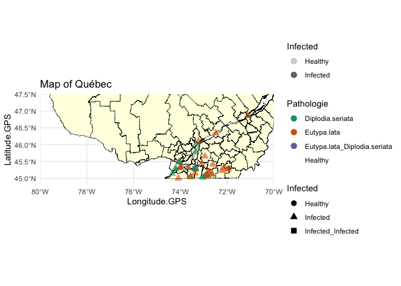

```r
# Map of vignobles

# Canada-wide boundary data (Level 1 = provinces/territories)
geodata_path("~/geodata")
canada_sp <- gadm(country = "CAN", level = 2)

# Filter for Quebec (assuming 'NAME_1' is the province name column)
quebec_sp <- subset(canada_sp, canada_sp$NAME_1 == "Québec")

# Convert to sf object for ggplot (optional but recommended)
quebec_sf <- st_as_sf(quebec_sp)
MBV16S_sampledata.envi <- MBV16S_mt$sample_table

MBV16S_sampledata.envi$Infected <- as.factor(
  str_replace_all(
    MBV16S_sampledata.envi$Pathologie,
    c(
      "Diplodia.seriata" = "Infected",
      "Eutypa.lata" = "Infected",
      "Eutypa.lata_Diplodia.seriata" = "Infected"
    )
  )
)
#levels(MBV16S_sampledata.envi$Infected) <- c("Healthy", "Infected", "Infected")

# plot map of all vineyards classified by symptomatic infections
ggplot() +
  geom_sf(data = quebec_sf, fill = "lightyellow", color = "black") +
  coord_sf(xlim = c(-80, -70), ylim = c(44.8, 47.5), expand = FALSE)+
  geom_point(data = MBV16S_sampledata.envi,                   # Specify the points data
             aes(x = Longitude.GPS, y = Latitude.GPS, shape = Infected, alpha = Infected, color = Pathologie), # Map aesthetics for points
             size = 3)+
  geom_jitter()+
  scale_color_manual(values = c("#1B9E77",  "#D95F02",  "#7570B3",  "NA"))+
  scale_alpha_manual(values = c("Healthy" = 0.2, "Infected" = 0.60))+
  labs(title = "Map of Québec") +
  theme_minimal()
```

### Taxonomic tables

#### Bacterial endophyte taxonomy

```r
bgenus_freq = sort(table((MBV16S_mt$tax_table)[, "Genus"], exclude = NULL), decreasing = TRUE)

top_bgenera <- names(bgenus_freq)[1:20]

tax_df <- as.data.frame(MBV16S_mt$tax_table)

tax_top_bgenera <- tax_df[tax_df$Genus %in% top_bgenera, ]

#collapse by one row per genus
tax_top_bgenera_unique <- tax_top_bgenera |>
  dplyr::select(Phylum, Class, Order, Family, Genus) |>
  dplyr::distinct()

#final table with frequencies
bacteria_final_table <- tax_top_bgenera_unique |>
  dplyr::left_join(
    data.frame(
      Genus = names(bgenus_freq),
      Frequency = as.numeric(bgenus_freq)
    ),
    by = "Genus"
  ) |>
  dplyr::arrange(desc(Frequency))

DT::datatable(bacteria_final_table)
```

|  | Phylum | Class | Order | Family | Genus | Frequency |
| --- | --- | --- | --- | --- | --- | --- |
| 1 | Proteobacteria | Gammaproteobacteria | Betaproteobacteriales | Burkholderiaceae |  | 535 |
| 2 | Proteobacteria | Alphaproteobacteria | Rhizobiales | Rhizobiaceae |  | 535 |
| 3 | Actinobacteria | Actinobacteria | Micrococcales | Microbacteriaceae |  | 535 |
| 4 | Proteobacteria | Gammaproteobacteria | Enterobacteriales | Enterobacteriaceae |  | 535 |
| 5 | Bacteroidetes | Bacteroidia | Sphingobacteriales | Sphingobacteriaceae |  | 535 |
| 6 | Proteobacteria | Alphaproteobacteria | Rhizobiales | Beijerinckiaceae |  | 535 |
| 7 | Proteobacteria | Alphaproteobacteria | Sphingomonadales | Sphingomonadaceae |  | 535 |
| 8 | Proteobacteria | Alphaproteobacteria | Rhizobiales | Methylopilaceae |  | 535 |
| 9 | Proteobacteria | Alphaproteobacteria | Rhizobiales | Devosiaceae |  | 535 |
| 10 | Actinobacteria | Actinobacteria | Frankiales | Geodermatophilaceae |  | 535 |

[output cut: 66 more lines]

#### Fungal endophyte taxonomy

```r
fgenus_freq = sort(table((MBVITS_mt$tax_table)[, "Genus"], exclude = NULL), decreasing = TRUE)

top_fgenera <- names(fgenus_freq)[1:20]

ftax_df <- as.data.frame(MBVITS_mt$tax_table)

tax_top_fgenera <- ftax_df[ftax_df$Genus %in% top_fgenera, ]

#collapse by one row per genus
tax_top_fgenera_unique <- tax_top_fgenera |>
  dplyr::select(Phylum, Class, Order, Family, Genus) |>
  dplyr::distinct()

#final table with frequencies
fungal_final_table <- tax_top_fgenera_unique |>
  dplyr::left_join(
    data.frame(
      Genus = names(fgenus_freq),
      Frequency = as.numeric(fgenus_freq)
    ),
    by = "Genus"
  ) |>
  dplyr::arrange(desc(Frequency))

DT::datatable(fungal_final_table)
```

|  | Phylum | Class | Order | Family | Genus | Frequency |
| --- | --- | --- | --- | --- | --- | --- |
| 1 | Ascomycota | Dothideomycetes | Pleosporales |  |  | 402 |
| 2 | Ascomycota | Dothideomycetes | Pleosporales | Melanommataceae |  | 402 |
| 3 | Ascomycota | Sordariomycetes | Xylariales |  |  | 402 |
| 4 | Ascomycota | Sordariomycetes | Hypocreales |  |  | 402 |
| 5 | Ascomycota |  |  |  |  | 402 |
| 6 | Ascomycota | Sordariomycetes |  |  |  | 402 |
| 7 | Ascomycota | Leotiomycetes | Helotiales |  |  | 402 |
| 8 | Ascomycota | Leotiomycetes | Helotiales | Sclerotiniaceae |  | 402 |
| 9 | Ascomycota | Sordariomycetes | Hypocreales | Nectriaceae |  | 402 |
| 10 | Basidiomycota | Agaricomycetes | Auriculariales | Exidiaceae |  | 402 |

[output cut: 50 more lines]

### Data exploration

#### Abundance differences endophyte across vineyards

- Bacterial endophyte

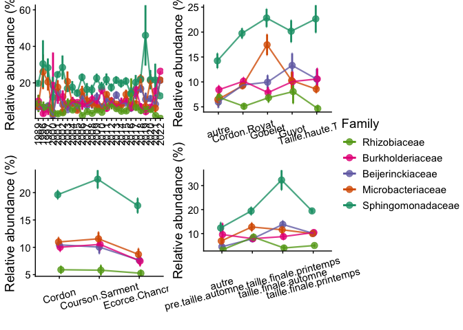

```r
# Variables plus important
#Annee.de.plantation    Mode.de.conduite    Periode.de.taille   Tissu
# Relative abundance
MBV16S_abunf <- trans_abund$new(dataset = MBV16S_mt, taxrank = "Family", ntaxa = 6)
MBV16S_abung <- trans_abund$new(dataset = MBV16S_mt, taxrank = "Genus")

# line plot by year planted
A_MBV16S_abunf <- trans_abund$new(dataset = MBV16S_mt, taxrank = "Family", ntaxa = 5, groupmean = "Annee.de.plantation")
A_MBV16S_abunf$data_abund <- A_MBV16S_abunf$data_abund %>%
  dplyr::filter(!is.na(Sample))
A_MBV16S_abun <- trans_abund$new(dataset = MBV16S_mt, taxrank = "Genus", ntaxa = 6, groupmean = "Annee.de.plantation")
A_MBV16S_abun$data_abund <- A_MBV16S_abun$data_abund %>%
  dplyr::filter(Sample != "NA",
                Taxonomy != "NA")
# vineyards sample tissue
B_MBV16S_abunf <- trans_abund$new(dataset = MBV16S_mt, taxrank = "Family", ntaxa = 5, groupmean = "Tissu")
B_MBV16S_abun <- trans_abund$new(dataset = MBV16S_mt, taxrank = "Genus", ntaxa = 6, groupmean = "Tissu")
B_MBV16S_abun$data_abund <- B_MBV16S_abun$data_abund %>%
  dplyr::filter(Taxonomy != "NA")
# vineyards training system
C_MBV16S_abunf <- trans_abund$new(dataset = MBV16S_mt, taxrank = "Family", ntaxa = 5, groupmean = "Mode.de.conduite")
C_MBV16S_abun <- trans_abund$new(dataset = MBV16S_mt, taxrank = "Genus", ntaxa = 6, groupmean = "Mode.de.conduite")
C_MBV16S_abun$data_abund <- C_MBV16S_abun$data_abund %>%
  dplyr::filter(Taxonomy != "NA")
# vineyards pruning season
D_MBV16S_abunf <- trans_abund$new(dataset = MBV16S_mt, taxrank = "Family", ntaxa = 5, groupmean = "Periode.de.taille")
D_MBV16S_abunf$data_abund <- D_MBV16S_abunf$data_abund %>%
  dplyr::filter(Sample != "")
D_MBV16S_abun <- trans_abund$new(dataset = MBV16S_mt, taxrank = "Genus", ntaxa = 6, groupmean = "Periode.de.taille")
D_MBV16S_abun$data_abund <- D_MBV16S_abun$data_abund %>%
  dplyr::filter(Sample != "",
                Taxonomy != "NA")

# Kruskal Wallis test genus tissue
kw_results <- MBV16S_abunf$data_abund %>%
  group_by(Taxonomy) %>%
  kruskal_test(Abundance ~ Tissu)
#correct multiple testing
kw_results <- kw_results %>%
  mutate(p_adj = p.adjust(p, method = "BH"))
#add significance labels
kw_results <- kw_results %>%
  mutate(p.signif = case_when(
    p_adj <= 0.001 ~ "***",
    p_adj <= 0.01  ~ "**",
    p_adj <= 0.05  ~ "*",
    TRUE           ~ "ns"
  ))

#
#posthoc <- MBV16S_abunf$data_abund %>%
#  group_by(Taxonomy) %>%
#  pairwise_wilcox_test(
#    Abundance ~ Tissu,
#    p.adjust.method = "BH", na.rm = TRUE)

# line plots
ggarrange(A_MBV16S_abunf$plot_line()+
  theme_classic()+ theme(axis.text.x = element_text(angle = 90, vjust = 0.5))+
  theme(text = element_text(size = 14)), C_MBV16S_abunf$plot_line()+
    theme_classic()+ theme(axis.text.x = element_text(angle = 15, vjust = 0.5))+
    theme(text = element_text(size = 14)), B_MBV16S_abunf$plot_line()+
    theme_classic()+ theme(axis.text.x = element_text(angle = 15, vjust = 0.5))+
    theme(text = element_text(size = 14)), D_MBV16S_abunf$plot_line()+
    theme_classic()+ theme(axis.text.x = element_text(angle = 15, vjust = 0.5))+
    theme(text = element_text(size = 14)), ncol= 2, nrow = 2, common.legend = TRUE, legend = "right")
```

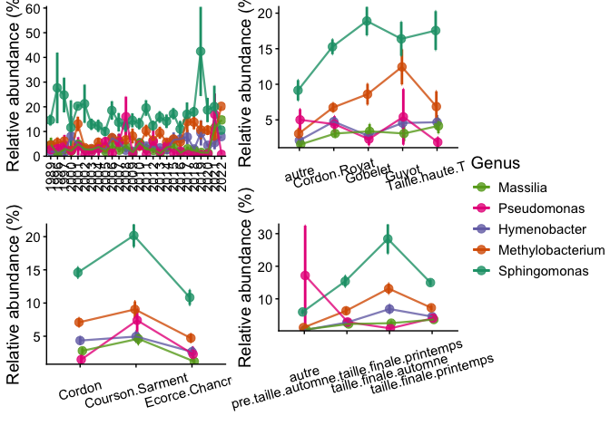

```r
ggarrange(A_MBV16S_abun$plot_line()+
            theme_classic()+ theme(axis.text.x = element_text(angle = 90, vjust = 0.5))+
            theme(text = element_text(size = 14)), C_MBV16S_abun$plot_line()+
            theme_classic()+ theme(axis.text.x = element_text(angle = 15, vjust = 0.5))+
            theme(text = element_text(size = 14)), B_MBV16S_abun$plot_line()+
            theme_classic()+ theme(axis.text.x = element_text(angle = 15, vjust = 0.5))+
            theme(text = element_text(size = 14)), D_MBV16S_abun$plot_line()+
            theme_classic()+ theme(axis.text.x = element_text(angle = 15, vjust = 0.5))+
            theme(text = element_text(size = 14)), ncol= 2, nrow = 2, common.legend = TRUE, legend = "right")
```

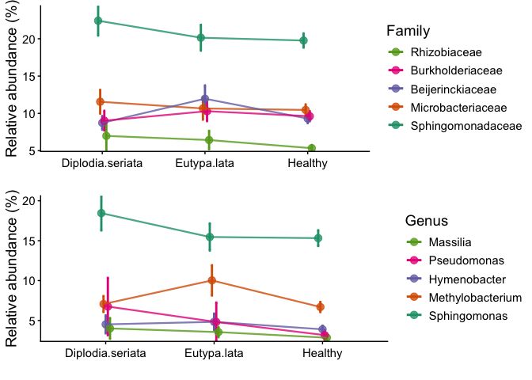

```r
# Infected plants

Pathos_MBV16S_abunf <- trans_abund$new(dataset = MBV16S_mt, taxrank = "Family", ntaxa = 5, groupmean = "Pathologie")
Pathos_MBV16S_abunf$data_abund <- Pathos_MBV16S_abunf$data_abund %>%
  dplyr::filter(Sample != "Eutypa.lata_Diplodia.seriata",
                Taxonomy != "NA")

Pathos_MBV16S_abung <- trans_abund$new(dataset = MBV16S_mt, taxrank = "Genus", ntaxa = 6, groupmean = "Pathologie")
Pathos_MBV16S_abung$data_abund <- Pathos_MBV16S_abung$data_abund %>%
  dplyr::filter(Sample != "Eutypa.lata_Diplodia.seriata",
                Taxonomy != "NA")

ggarrange(Pathos_MBV16S_abunf$plot_line()+
            theme_classic()+ theme(axis.text.x = element_text(angle = 0, vjust = 0.5))+
            theme(text = element_text(size = 14)), Pathos_MBV16S_abung$plot_line()+
            theme_classic()+ theme(axis.text.x = element_text(angle = 0, vjust = 0.5))+
            theme(text = element_text(size = 14)), ncol= 1, nrow = 2)
```

- Fungal endophyte

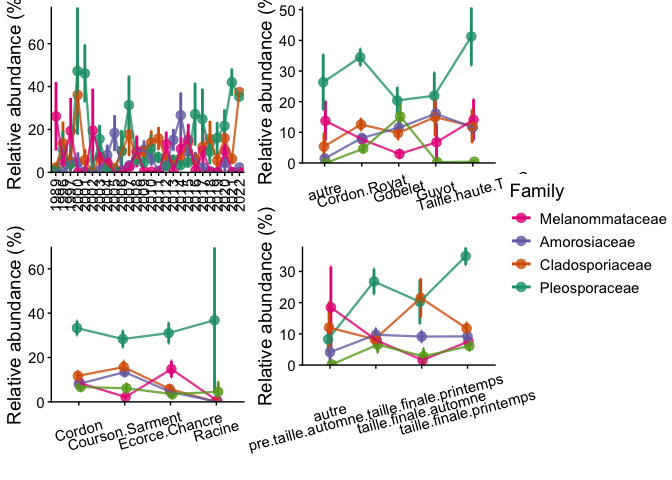

```r
# Sum sample coverage
MBVITS_mt$sample_table$coverage = MBVITS_mt$sample_sums()

# Relative abundance
MBVITS_abunf <- trans_abund$new(dataset = MBVITS_mt, taxrank = "Family")
MBVITS_abung <- trans_abund$new(dataset = MBVITS_mt, taxrank = "Genus")

# line plot by year planted
# vineyard year of plantation
A_MBVITS_abunf <- trans_abund$new(dataset = MBVITS_mt, taxrank = "Family", ntaxa = 5, groupmean = "Annee.de.plantation")
A_MBVITS_abunf$data_abund <- A_MBVITS_abunf$data_abund %>%
  dplyr::filter(!is.na(Sample),
                Taxonomy != "NA")
A_MBVITS_abun <- trans_abund$new(dataset = MBVITS_mt, taxrank = "Genus", ntaxa = 6, groupmean = "Annee.de.plantation")
A_MBVITS_abun$data_abund <- A_MBVITS_abun$data_abund %>%
  dplyr::filter(Sample != "NA",
                Taxonomy != "NA")
# Plant tissue
B_MBVITS_abunf <- trans_abund$new(dataset = MBVITS_mt, taxrank = "Family", ntaxa = 5, groupmean = "Tissu")
B_MBVITS_abun <- trans_abund$new(dataset = MBVITS_mt, taxrank = "Genus", ntaxa = 6, groupmean = "Tissu")
B_MBVITS_abun$data_abund <- B_MBVITS_abun$data_abund %>%
  dplyr::filter(Taxonomy != "NA")
# vineyard training system
C_MBVITS_abunf <- trans_abund$new(dataset = MBVITS_mt, taxrank = "Family", ntaxa = 5, groupmean = "Mode.de.conduite")
C_MBVITS_abun <- trans_abund$new(dataset = MBVITS_mt, taxrank = "Genus", ntaxa = 6, groupmean = "Mode.de.conduite")
C_MBVITS_abun$data_abund <- C_MBVITS_abun$data_abund %>%
  dplyr::filter(Taxonomy != "NA")
# vineyard pruning season
D_MBVITS_abunf <- trans_abund$new(dataset = MBVITS_mt, taxrank = "Family", ntaxa = 5, groupmean = "Periode.de.taille")
D_MBVITS_abunf$data_abund <- D_MBVITS_abunf$data_abund %>%
  dplyr::filter(Sample != "")
D_MBVITS_abun <- trans_abund$new(dataset = MBVITS_mt, taxrank = "Genus", ntaxa = 6, groupmean = "Periode.de.taille")
D_MBVITS_abun$data_abund <- D_MBVITS_abun$data_abund %>%
  dplyr::filter(Sample != "",
                Taxonomy != "NA")



# Kruskal Wallis test genus tissue
kw_results <- MBVITS_abunf$data_abund %>%
  group_by(Taxonomy) %>%
  kruskal_test(Abundance ~ Sample)
#correct multiple testing
kw_results <- kw_results %>%
  mutate(p_adj = p.adjust(p, method = "BH"))
#add significance labels
kw_results <- kw_results %>%
  mutate(p.signif = case_when(
    p_adj <= 0.001 ~ "***",
    p_adj <= 0.01  ~ "**",
    p_adj <= 0.05  ~ "*",
    TRUE           ~ "ns"
  ))

# post hot test
#posthoc <- MBVITS_abunf$data_abund %>%
#  group_by(Taxonomy) %>%
#  pairwise_wilcox_test(
#    Abundance ~ Sample,
#    p.adjust.method = "BH")

#check abundance distribution of significant taxa
ggarrange(A_MBVITS_abunf$plot_line()+
            theme_classic()+ theme(axis.text.x = element_text(angle = 90, vjust = 0.5))+
            theme(text = element_text(size = 14)), C_MBVITS_abunf$plot_line()+
            theme_classic()+ theme(axis.text.x = element_text(angle = 15, vjust = 0.5))+
            theme(text = element_text(size = 14)), B_MBVITS_abunf$plot_line()+
            theme_classic()+ theme(axis.text.x = element_text(angle = 15, vjust = 0.5))+
            theme(text = element_text(size = 14)), D_MBVITS_abunf$plot_line()+
            theme_classic()+ theme(axis.text.x = element_text(angle = 15, vjust = 0.5))+
            theme(text = element_text(size = 14)), ncol= 2, nrow = 2, common.legend = TRUE, legend = "right")
```

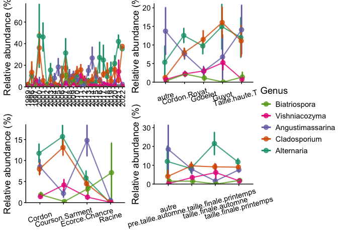

```r
ggarrange(A_MBVITS_abun$plot_line()+
            theme_classic()+ theme(axis.text.x = element_text(angle = 90, vjust = 0.5))+
            theme(text = element_text(size = 14)), C_MBVITS_abun$plot_line()+
            theme_classic()+ theme(axis.text.x = element_text(angle = 15, vjust = 0.5))+
            theme(text = element_text(size = 14)), B_MBVITS_abun$plot_line()+
            theme_classic()+ theme(axis.text.x = element_text(angle = 15, vjust = 0.5))+
            theme(text = element_text(size = 14)), D_MBVITS_abun$plot_line()+
            theme_classic()+ theme(axis.text.x = element_text(angle = 15, vjust = 0.5))+
            theme(text = element_text(size = 14)), ncol= 2, nrow = 2, common.legend = TRUE, legend = "right")
```

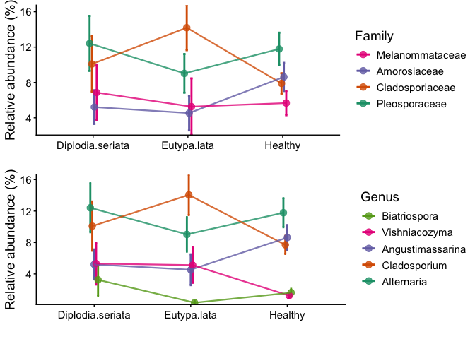

```r
# Infected plants

Pathos_MBVITS_abunf <- trans_abund$new(dataset = MBVITS_mt, taxrank = "Family", ntaxa = 5, groupmean = "Pathologie")
Pathos_MBVITS_abunf$data_abund <- Pathos_MBVITS_abunf$data_abund %>%
  dplyr::filter(Sample != "Eutypa.lata_Diplodia.seriata",
                Taxonomy != "NA")

Pathos_MBVITS_abung <- trans_abund$new(dataset = MBVITS_mt, taxrank = "Genus", ntaxa = 6, groupmean = "Pathologie")
Pathos_MBVITS_abung$data_abund <- Pathos_MBVITS_abung$data_abund %>%
  dplyr::filter(Sample != "Eutypa.lata_Diplodia.seriata",
                Taxonomy != "NA")

ggarrange(Pathos_MBVITS_abunf$plot_line()+
            theme_classic()+ theme(axis.text.x = element_text(angle = 0, vjust = 0.5))+
            theme(text = element_text(size = 14)), Pathos_MBVITS_abung$plot_line()+
            theme_classic()+ theme(axis.text.x = element_text(angle = 0, vjust = 0.5))+
            theme(text = element_text(size = 14)), ncol= 1, nrow = 2)
```

### Alpha-diversity

General script for alpha diversity estimates

```r
# Diversity
### Alpha diversity general
set.seed(6565)

# general script to estimate diversity index for bacterial and fungal endophytes using Hill numbers
MBV_alpha <- trans_alpha$new(dataset = MBV_mt, group = "Tissu", by_group = "Infected", by_ID = "Echantillon")# group by tissue sampled
# transform taxa occurence to relative abundance
MBV_mt_norm <- microbiome::transform(MBV_mt$otu_table, transform = "compositional")

###alpha diversity
#observe species hill numbers
hillq0 <- subset(MBV_alpha$data_alpha, MBV_alpha$data_alpha$Measure == "Observed")

# Shannon
shannon.hill <- exp(vegan::diversity(t(MBV_mt_norm), index = "shannon"))

# Simpson
simpson.hill <- 1/(1-(vegan::diversity(t(MBV_mt_norm), index = "simpson")))
```

- Bacteria

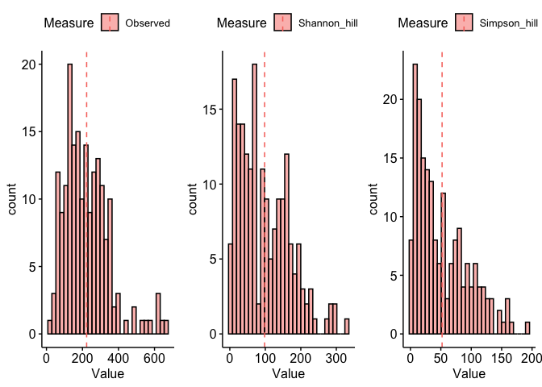

```r
# Statistics of both bacteria and fungi
# check for normality with histrogram
ggarrange(gghistogram(subset(MBV16S_alpha$data_alpha, MBV16S_alpha$data_alpha$Measure == "Observed"), "Value", y = "count", fill = "Measure",
            add = "mean"),
gghistogram(subset(MBV16S_alpha$data_alpha, MBV16S_alpha$data_alpha$Measure == "Shannon_hill"), "Value", y = "count", fill = "Measure",
            add = "mean"),
gghistogram(subset(MBV16S_alpha$data_alpha, MBV16S_alpha$data_alpha$Measure == "Simpson_hill"), "Value", y = "count", fill = "Measure",
            add = "mean"), nrow = 1, ncol = 3)
```

```r
#Bacteria
#data.frame(shapiro.test(subset(MBV16S_alpha$data_alpha, MBV16S_alpha$data_alpha$Measure == "Observed")[,3])[1:4],
#shapiro.test(subset(MBV16S_alpha$data_alpha, MBV16S_alpha$data_alpha$Measure == "Shannon_hill")[,3])[1:4],
#shapiro.test(subset(MBV16S_alpha$data_alpha, MBV16S_alpha$data_alpha$Measure == "Simpson_hill")[,3])[1:4])
```

- Fungi

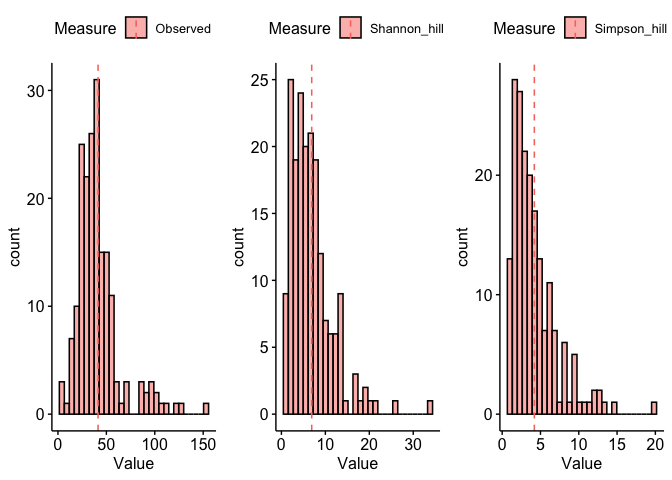

```r
### Fungi
ggarrange(gghistogram(subset(MBVITS_alpha$data_alpha, MBVITS_alpha$data_alpha$Measure == "Observed"), "Value", y = "count", fill = "Measure",
            add = "mean"),
gghistogram(subset(MBVITS_alpha$data_alpha, MBVITS_alpha$data_alpha$Measure == "Shannon_hill"), "Value", y = "count", fill = "Measure",
            add = "mean"),
gghistogram(subset(MBVITS_alpha$data_alpha, MBVITS_alpha$data_alpha$Measure == "Simpson_hill"), "Value", y = "count", fill = "Measure",
            add = "mean"), nrow = 1, ncol = 3)
```

```r
#data.frame(shapiro.test(subset(MBVITS_alpha$data_alpha, MBVITS_alpha$data_alpha$Measure == "Observed")[,3])[1:4],
#                     shapiro.test(subset(MBVITS_alpha$data_alpha, MBVITS_alpha$data_alpha$Measure == "Shannon_hill")[,3])[1:4],
#                     shapiro.test(subset(MBVITS_alpha$data_alpha, MBVITS_alpha$data_alpha$Measure == "Simpson_hill")[,3])[1:4])
```

#### Alpha-diversity statistical analyses

```r
# Alpha diversity summary statistics
########
# estimate mean and standard deviation for groups
data_summary <- function(data, varname, groupnames){
  require(plyr)
  summary_func <- function(x, col){
    c(mean = mean(x[[col]], na.rm=TRUE),
      sd = sd(x[[col]], na.rm=TRUE))
  }
  data_sum<-ddply(data, groupnames, .fun=summary_func,
                  varname)
  data_sum <- rename(data_sum, c("mean" = varname))
  return(data_sum)
}

#
Bacterialmeandiv = data.frame(dfrich.obs.b <- data_summary(subset(MBV16S_alpha$data_alpha, MBV16S_alpha$data_alpha$Measure == "Observed"), varname="Value", groupnames=c("Annee.echantillonnage.fact", "Tissu", "Infected")),
                           dfrich.sha.b <- data_summary(subset(MBV16S_alpha$data_alpha, MBV16S_alpha$data_alpha$Measure == "Shannon_hill"), varname="Value", groupnames=c("Annee.echantillonnage.fact", "Tissu", "Infected")),
                           dfrich.simp.b <- data_summary(subset(MBV16S_alpha$data_alpha, MBV16S_alpha$data_alpha$Measure == "Simpson_hill"), varname="Value", groupnames=c("Annee.echantillonnage.fact", "Tissu", "Infected")))

Fungalmeandiv = data.frame(dfrich.obs.plot <- data_summary(subset(MBVITS_alpha$data_alpha, MBVITS_alpha$data_alpha$Measure == "Observed"), varname="Value", groupnames=c("Annee.echantillonnage.fact", "Tissu", "Infected")),
                     dfrich.sha.plot <- data_summary(subset(MBVITS_alpha$data_alpha, MBVITS_alpha$data_alpha$Measure == "Shannon_hill"), varname="Value", groupnames=c("Annee.echantillonnage.fact", "Tissu", "Infected")),
                     dfrich.simp.plot <- data_summary(subset(MBVITS_alpha$data_alpha, MBVITS_alpha$data_alpha$Measure == "Simpson_hill"), varname="Value", groupnames=c("Annee.echantillonnage.fact", "Tissu", "Infected")))


summary(glm(Value~Tissu*Infected, family = Gamma(link = "log"), data=subset(MBV16S_alpha$data_alpha, MBV16S_alpha$data_alpha$Measure == "Observed")))
summary(glm(Value~Tissu*Infected, family = Gamma(link = "log"), data=subset(MBV16S_alpha$data_alpha, MBV16S_alpha$data_alpha$Measure == "Shannon_hill")))
summary(glm(Value~Tissu*Infected, family = Gamma(link = "log"), data=subset(MBV16S_alpha$data_alpha, MBV16S_alpha$data_alpha$Measure == "Simpson_hill")))

summary(glm(Value~Tissu*Infected, family = Gamma(link = "log"), data=subset(MBVITS_alpha$data_alpha, MBVITS_alpha$data_alpha$Measure == "Observed")))
summary(glm(Value~Tissu*Infected, family = Gamma(link = "log"), data=subset(MBVITS_alpha$data_alpha, MBVITS_alpha$data_alpha$Measure == "Shannon_hill")))
summary(glm(Value~Tissu*Infected, family = Gamma(link = "log"), data=subset(MBVITS_alpha$data_alpha, MBVITS_alpha$data_alpha$Measure == "Simpson_hill")))
```

#### Visualize alpha-diversity

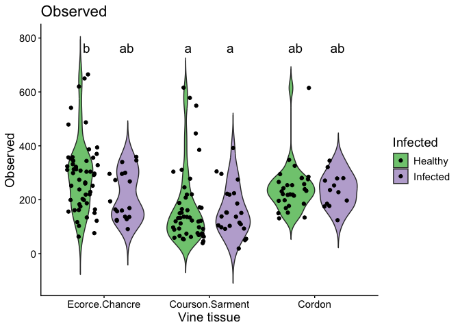

```r
#Visualize
#bacteria
library(introdataviz)
library(devtools)
#devtools::install_github("psyteachr/introdataviz")
library(purrr)
library(emmeans)
library(multcomp)


div_measures <- c("Observed", "Shannon_hill", "Simpson_hill")
levels(MBV16S_alpha$data_alpha$Tissu) = c("Ecorce.Chancre", "Courson.Sarment","Cordon")

plot_list_bacteria <- list()

for (measure in div_measures) {

    df_sub <- MBV16S_alpha$data_alpha %>%
      filter(Measure == measure)
  # ---- Fit GLM ----
  model <- glm(Value ~ Tissu * Infected,
               data = df_sub,
               family = Gamma(link = "log"))

  # ---- Estimated marginal means ----
  emm <- emmeans(model, ~ Tissu * Infected)

  # ---- Compact letter display ----
  cld_res <- multcomp::cld(emm, Letters = letters) %>%
    as.data.frame()
  cld_res$maxval = max(df_sub$Value)
  # ---- Plot ----
  p <- ggplot(df_sub,
              aes(x = Tissu,
                  y = Value,
                  fill = Infected)) +

    geom_violin(trim = FALSE) +

    geom_jitter(position = position_jitterdodge(
                  dodge.width = 0.8,
                  jitter.width = 0.6),
                size = 1.5) +

    geom_text(data = cld_res,
              aes(x = Tissu,
                  y = maxval+100,
                  label = .group,
                  group = Infected),
              position = position_dodge(0.8),
              inherit.aes = FALSE,
              size = 5) +
    labs(x = "Vine tissue",
         y = measure,
         title = measure) +
    scale_fill_brewer(palette = "Accent") +
    theme_classic() +
    theme(text = element_text(size = 14))

  plot_list_bacteria[[measure]] <- p
}

plot_list_bacteria[[1]]
```

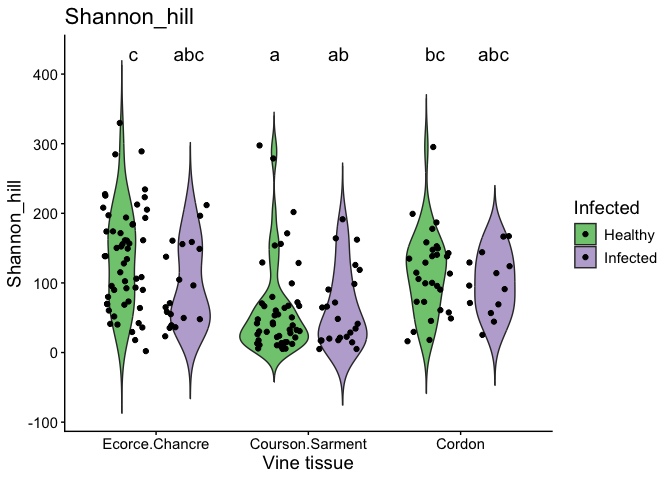

```r
plot_list_bacteria[[2]]
```

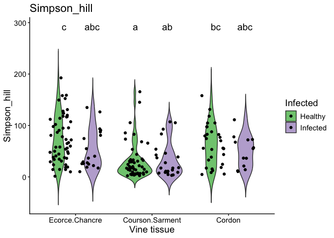

```r
plot_list_bacteria[[3]]
```

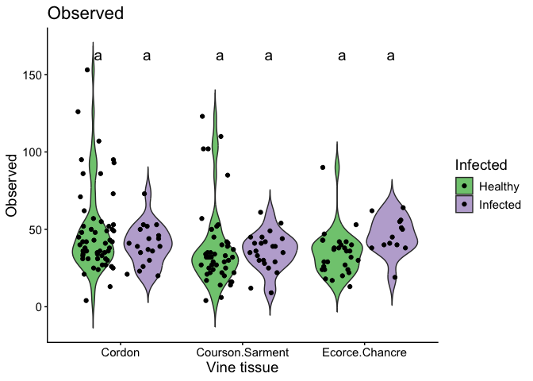

```r
### plot fungi
MBVITS_alpha_sub <- NULL
MBVITS_alpha_sub$data_alpha <- MBVITS_alpha$data_alpha %>%
  filter(Tissu != "Racine")

plot_list_fungi <- list()
for (measure in div_measures) {

  df_sub <- MBVITS_alpha_sub$data_alpha %>%
    filter(Measure == measure)
  # ---- Fit GLM ----
  model <- glm(Value ~ Tissu * Infected,
               data = df_sub,
               family = Gamma(link = "log"))

  # ---- Estimated marginal means ----
  emm <- emmeans(model, ~ Tissu * Infected)

  # ---- Compact letter display ----
  cld_res <- multcomp::cld(emm, Letters = letters) %>%
    as.data.frame()
  cld_res$maxval = max(df_sub$Value)
  # ---- Plot ----
  p <- ggplot(df_sub,
              aes(x = Tissu,
                  y = Value,
                  fill = Infected)) +

    geom_violin(trim = FALSE) +

    geom_jitter(position = position_jitterdodge(
      dodge.width = 0.8,
      jitter.width = 0.6),
      size = 1.5) +

    geom_text(data = cld_res,
              aes(x = Tissu,
                  y = maxval+10,
                  label = .group,
                  group = Infected),
              position = position_dodge(0.8),
              inherit.aes = FALSE,
              size = 5) +
    labs(x = "Vine tissue",
         y = measure,
         title = measure) +
    scale_fill_brewer(palette = "Accent") +
    theme_classic() +
    theme(text = element_text(size = 14))

  plot_list_fungi[[measure]] <- p
}

plot_list_fungi[[1]]
```

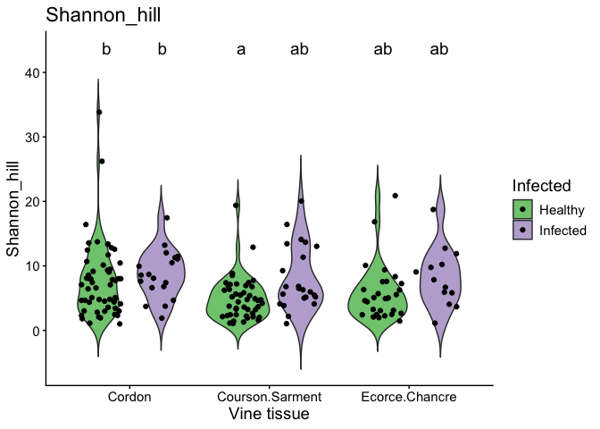

```r
plot_list_fungi[[2]]
```

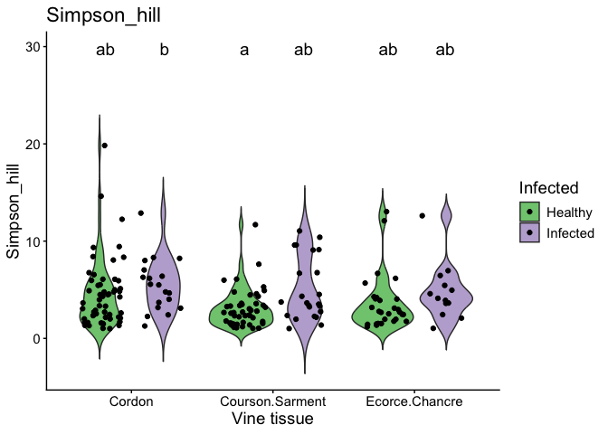

```r
plot_list_fungi[[3]]
```

### Beta-diversity

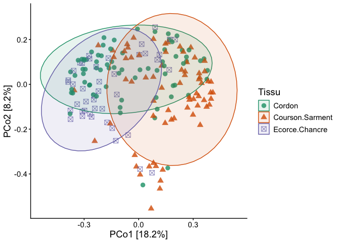

```r
#########Beta diversity
# Betadiversity Analysis by tissue as principal group
#"Tissu"
#Bacteria
MBV16S_mt$cal_betadiv()
bact.beta <- trans_beta$new(dataset = MBV16S_mt, group = "Tissu", measure = "bray")

bact.beta$cal_ordination(method = "PCoA")
# $res_ordination is the ordination result list

#bacteria plot by tissue
bact.beta$plot_ordination(plot_color = "Tissu", plot_shape = "Tissu", plot_type = c("point", "ellipse"))+
  theme_classic() +
  theme(text = element_text(size = 14))
```

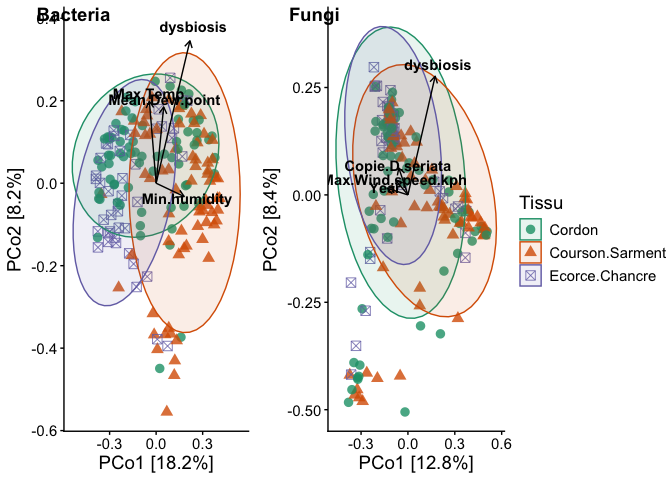

```r
#Fungal
MBVITS_mt$sample_table = MBVITS_mt$sample_table %>%
  filter(Tissu != "Racine")
MBVITS_mt$tidy_dataset()

MBVITS_abun <- trans_abund$new(dataset = MBVITS_mt)
MBVITS_mt$cal_betadiv()

fung.beta <- trans_beta$new(dataset = MBVITS_mt, group = "Tissu", measure = "bray")

fung.beta$cal_ordination(method = "PCoA")
# t1$res_ordination is the ordination result list


#envfit (community-level effects) bacteria
#Ordination
ord_scores_bact <- scores(bact.beta$res_ordination, display = "sites")

MBVenvi.data.vars<-ord_scores_bact[,c(19:20,27:38)]
MBVenvi.data.vars$dysbiosis <- dysbiosis_results_bacteria$dysbiosisOOBRF$oob.score
# Fit environmental data

fit_bact <- envfit(ord_scores_bact[,c(1:2)], MBVenvi.data.vars, permutations = 999, na.rm = TRUE)
#fit_bact_sig<-data.frame(fit_bact$vectors)

# Extract the arrow coordinates
# These are the x and y directions of the arrows
arrows_bact <- as.data.frame(scores(fit_bact, display = "vectors"))
arrows_bact$r <- fit_bact$vectors$r
arrows_bact$pvals <- fit_bact$vectors$pvals
arrows_bact$vars <- rownames(arrows_bact)
arrows_bact_sig <- arrows_bact[which(arrows_bact$pvals < 0.06),]
# Multiply arrows by a factor so they are visible
# (sometimes they are too small/large relative to the points)
scaling_factor <- 0.8
arrows_bact[,1:2] <- arrows_bact[,1:2] * scaling_factor

#envfit (community-level effects) fungi
#Ordination
ord_scores_fung <- scores(fung.beta$res_ordination, display = "sites")


MBVenvi.data.vars.fung<-ord_scores_fung[,c(19:20,27:38)]

dysbiosis_results_fungi$dysbiosisOOBRF = dysbiosis_results_fungi$dysbiosisOOBRF %>%
  filter(Tissu != "Racine")
MBVenvi.data.vars.fung$dysbiosis <- dysbiosis_results_fungi$dysbiosisOOBRF$oob.score
ord_scores_fung$dysbiosisOOBRF = dysbiosis_results_fungi$dysbiosisOOBRF$oob.score
# Fit environmental datas

fit_fung <- envfit(ord_scores_fung[,c(1:2)], MBVenvi.data.vars.fung, permutations = 999, na.rm = TRUE)


# Extract the arrow coordinates
# These are the x and y directions of the arrows
arrows_fung <- as.data.frame(scores(fit_fung, display = "vectors"))
arrows_fung$r <- fit_fung$vectors$r
arrows_fung$pvals <- fit_fung$vectors$pvals
arrows_fung$vars <- rownames(arrows_fung)
arrows_fung_sig <- arrows_bact[which(arrows_fung$pvals < 0.06),]
# Multiply arrows by a factor so they are visible
# (sometimes they are too small/large relative to the points)
scaling_factor <- 0.8
arrows_fung[,1:2] <- arrows_fung[,1:2] * scaling_factor
# plot the PCoA result with confidence ellipse
#for bacteria and fingi
ggarrange(bact.beta$plot_ordination(plot_color = "Tissu", plot_shape = "Tissu", plot_type = c("point", "ellipse"))+
            geom_segment(data = arrows_bact_sig,
                         aes(x = 0, y = 0, xend = PCo1, yend = PCo2),
                         arrow = arrow(length = unit(0.2, "cm")),
                         color = "black", inherit.aes = FALSE) +
            geom_text(data = arrows_bact_sig,
                      aes(x = PCo1 * 1.1, y = PCo2 * 1.1, label = vars),
                      color = "black", fontface = "bold", inherit.aes = FALSE) +
  theme_classic() +
  theme(text = element_text(size = 14)), fung.beta$plot_ordination(plot_color = "Tissu", plot_shape = "Tissu", plot_type = c("point", "ellipse"))+
    geom_segment(data = arrows_fung_sig,
                aes(x = 0, y = 0, xend = PCo1, yend = PCo2),
                arrow = arrow(length = unit(0.2, "cm")),
                color = "black", inherit.aes = FALSE) +
    geom_text(data = arrows_fung_sig,
              aes(x = PCo1 * 1.1, y = PCo2 * 1.1, label = vars),
              color = "black", fontface = "bold", inherit.aes = FALSE) +
    theme_classic() +
  theme(text = element_text(size = 14)), ncol = 2, labels = c("Bacteria", " Fungi"), common.legend = TRUE, legend = "right")
```

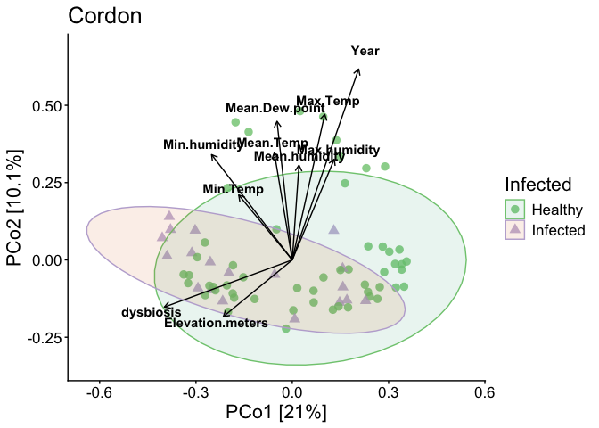

```r
#### Loop for generating ordination plots by tissues

# Define tissues
tissues <- c("Cordon", "Courson.Sarment", "Ecorce.Chancre")
MBV16S_mt$sample_table$dysbiosis <- dysbiosis_results_bacteria$dysbiosisOOBRF$oob.score


# Empty list to store plots for bacteria
ordination_plots_bact <- list()

for (tissue in tissues) {

  # Filter sample table
  sub_micro <-clone(MBV16S_mt)
  sub_micro$sample_table <- subset(sub_micro$sample_table, Tissu == tissue)
  sub_micro$cal_betadiv()
  bact.beta.sub <- trans_beta$new(dataset = sub_micro, group = "Infected", measure = "bray")

  bact.beta.sub$cal_ordination(method = "PCoA")
    # Optional: inspect tidy dataset
  df <- sub_micro$tidy_dataset
  print(paste(tissue, "samples:", nrow(df)))
  #enfit
  #Ordination
  ord_scores_bact <- scores(bact.beta.sub$res_ordination, display = "sites")

  MBVenvi.data.vars<-ord_scores_bact[,c(19:20,27,29:38,43)]
  # 2. Fit environmental datas

  fit_bact <- envfit(ord_scores_bact[,c(1:2)], MBVenvi.data.vars, permutations = 999, na.rm = TRUE)
  # 3. Extract the arrow coordinates
  # These are the x and y directions of the arrows
  arrows_bact <- as.data.frame(scores(fit_bact, display = "vectors"))
  arrows_bact$r <- fit_bact$vectors$r
  arrows_bact$pvals <- fit_bact$vectors$pvals
  arrows_bact$vars <- rownames(arrows_bact)
  arrows_bact_sigt <- arrows_bact[which(arrows_bact$pvals < 0.06),]
  # 4. Optional: Multiply arrows by a factor so they are visible
  # (sometimes they are too small/large relative to the points)
  scaling_factor <- 0.8
  arrows_bact_sigt[,1:2] <- arrows_bact_sigt[,1:2] * scaling_factor
# Generate ordination plot
  p <- bact.beta.sub$plot_ordination(
    plot_color = "Infected",
    plot_shape = "Infected",
    plot_type = c("point", "ellipse")
  )+
    geom_segment(data = arrows_bact_sigt,
                 aes(x = 0, y = 0, xend = PCo1, yend = PCo2),
                 arrow = arrow(length = unit(0.2, "cm")),
                 color = "black", inherit.aes = FALSE) +
    geom_text(data = arrows_bact_sigt,
              aes(x = PCo1 * 1.1, y = PCo2 * 1.1, label = vars),
              color = "black", fontface = "bold", inherit.aes = FALSE) +
    labs(title = tissue) +
    scale_color_brewer(palette = "Accent") +
    theme_classic() +
    theme(text = element_text(size = 16))

  # Store in list
  ordination_plots_bact[[tissue]] <- p
}

# display the Cordon plot
ordination_plots_bact$Cordon
```

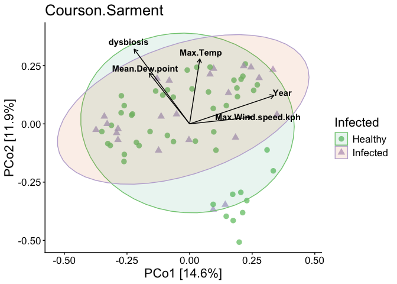

```r
ordination_plots_bact$Courson.Sarment
```

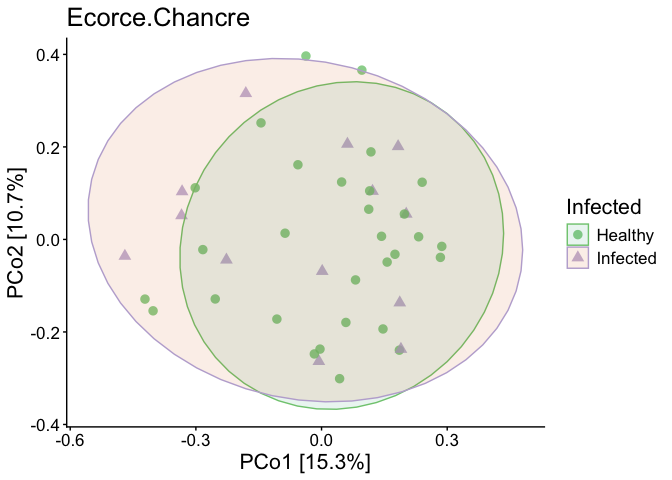

```r
ordination_plots_bact$Ecorce.Chancre
```

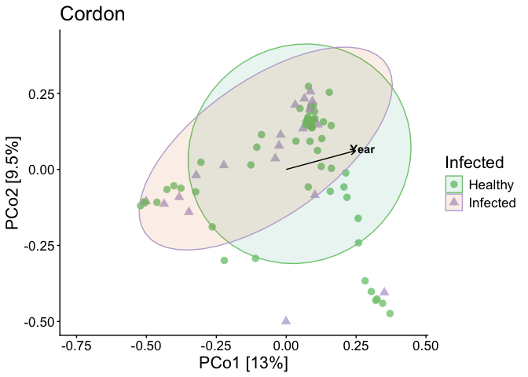

```r
# Empty list to store plots for fungi
MBVITS_mt$sample_table$dysbiosis <- dysbiosis_results_fungi$dysbiosisOOBRF$oob.score


ordination_plots_fung <- list()

for (tissue in tissues) {
  # Filter sample table
  sub_micro <-clone(MBVITS_mt)
  sub_micro$sample_table <- subset(sub_micro$sample_table, Tissu == tissue)
  sub_micro$cal_betadiv()
  fung.beta.sub <- trans_beta$new(dataset = sub_micro, group = "Infected", measure = "bray")

  fung.beta.sub$cal_ordination(method = "PCoA")
  # Optional: inspect tidy dataset
  df <- sub_micro$tidy_dataset
  print(paste(tissue, "samples:", nrow(df)))
  #enfit
  #Ordination
  ord_scores_fung <- scores(fung.beta.sub$res_ordination, display = "sites")
  colnames(ord_scores_fung)
  MBVenvi.data.vars<-ord_scores_fung[,c(19:20,27,29:38,41)]
  # Fit environmental datas
  fit_fung <- envfit(ord_scores_fung[,c(1:2)], MBVenvi.data.vars, permutations = 999, na.rm = TRUE)
  # 3. Extract the arrow coordinates
  # These are the x and y directions of the arrows
  arrows_fung <- as.data.frame(scores(fit_fung, display = "vectors"))
  arrows_fung$r <- fit_fung$vectors$r
  arrows_fung$pvals <- fit_fung$vectors$pvals
  arrows_fung$vars <- rownames(arrows_fung)
  arrows_fung_sigt <- arrows_fung[which(arrows_fung$pvals < 0.06),]
  #  Multiply arrows by a factor so they are visible
  # (sometimes they are too small/large relative to the points)
  scaling_factor <- 0.8
  arrows_fung_sigt[,1:2] <- arrows_fung_sigt[,1:2] * scaling_factor
  # Generate ordination plot
  p <- fung.beta.sub$plot_ordination(
    plot_color = "Infected",
    plot_shape = "Infected",
    plot_type = c("point", "ellipse")
  )+
    geom_segment(data = arrows_fung_sigt,
                 aes(x = 0, y = 0, xend = PCo1, yend = PCo2),
                 arrow = arrow(length = unit(0.2, "cm")),
                 color = "black", inherit.aes = FALSE) +
    geom_text(data = arrows_fung_sigt,
              aes(x = PCo1 * 1.1, y = PCo2 * 1.1, label = vars),
              color = "black", fontface = "bold", inherit.aes = FALSE) +
    xlim(-0.75, NA)+labs(title = tissue) +
    scale_color_brewer(palette = "Accent") +
    theme_classic() +
    theme(text = element_text(size = 16))

  # Store in list
  ordination_plots_fung[[tissue]] <- p
}

# display the Cordon plot

ordination_plots_fung$Cordon
```

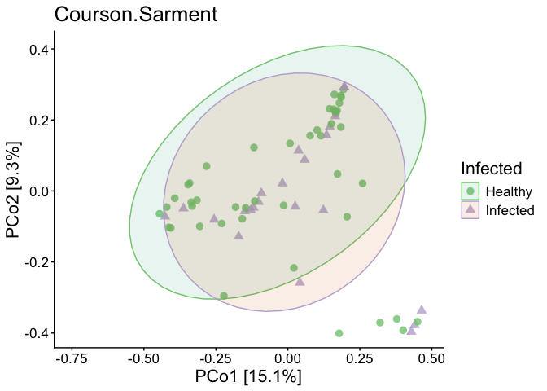

```r
ordination_plots_fung$Courson.Sarment
```

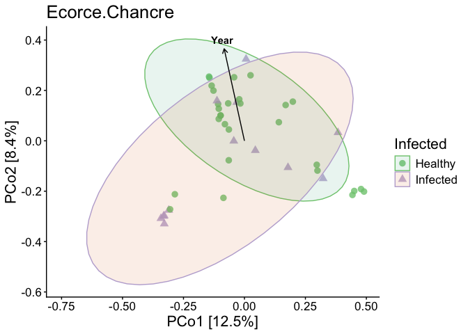

```r
ordination_plots_fung$Ecorce.Chancre
```

#### Betadiversity statistical analyses and ordination distances within groups

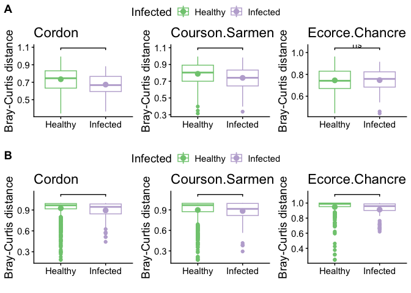

```r
# calculate and plot sample distances within groups

# Empty list to store plots for bacteria
distance_plots_bact <- list()

for (tissue in tissues) {
  # Filter sample table
  sub_micro <-clone(MBV16S_mt)
  sub_micro$sample_table <- subset(sub_micro$sample_table, Tissu == tissue)
  sub_micro$cal_betadiv()
  bact.beta.sub <- trans_beta$new(dataset = sub_micro, group = "Infected", measure = "bray")
  bact.beta.sub$cal_group_distance(within_group = TRUE)
  bact.beta.sub$cal_group_distance_diff(method = "wilcox")
  # plot_group_order parameter can be used to adjust orders in x axis
  # Store in list
  distance_plots_bact[[tissue]] <- bact.beta.sub$plot_group_distance(add = "mean")+
    labs(title = tissue) +
    scale_color_brewer(palette = "Accent") +
    theme_classic() +
    theme(text = element_text(size = 14))
}
#fungi
distance_plots_fung <- list()

for (tissue in tissues) {

  # Filter sample table
  sub_micro <-clone(MBVITS_mt)
  sub_micro$sample_table <- subset(sub_micro$sample_table, Tissu == tissue)
  sub_micro$cal_betadiv()
  fung.beta.sub <- trans_beta$new(dataset = sub_micro, group = "Infected", measure = "bray")
  fung.beta.sub$cal_group_distance(within_group = TRUE)
  fung.beta.sub$cal_group_distance_diff(method = "wilcox")
  # plot_group_order parameter can be used to adjust orders in x axis
  # Store in list
  distance_plots_fung[[tissue]] <- fung.beta.sub$plot_group_distance(add = "mean")+
    labs(title = tissue) +
    scale_color_brewer(palette = "Accent") +
    theme_classic() +
    theme(text = element_text(size = 14))
}

ggarrange(ggarrange(plotlist = distance_plots_bact, nrow = 1, ncol = 3, common.legend = TRUE),
          ggarrange(plotlist = distance_plots_fung,nrow = 1, ncol = 3, common.legend = TRUE),
          nrow = 2, labels = c("A", "B"))
```

```r
bact.beta$cal_group_distance(within_group = FALSE)

# perform Wilcoxon Rank Sum and Signed Rank Tests
bact.beta$cal_group_distance_diff(method = "wilcox")

# calculate and plot sample distances within groups
fung.beta$cal_group_distance(within_group = TRUE)
# perform Wilcoxon Rank Sum and Signed Rank Tests
fung.beta$cal_group_distance_diff(method = "wilcox")

# Bacteria
# Permanova
bact.beta$cal_manova(manova_all = FALSE, group = "Tissu", by_group = "Infected")
## Multivariate homogeneity of groups dispersions (variances)
bact.beta$cal_betadisper()
bact.beta$res_betadisper
#Fungi
#Permanova
fung.beta$cal_manova(manova_all = FALSE, group = "Tissu", by_group = "Infected")
fung.beta$res_manova
## Multivariate homogeneity of groups dispersions (variances)
#
fung.beta$cal_betadisper()
fung.beta$res_betadisper
#PERMANOVA
# manova for all groups when manova_all = TRUE
bact.beta$cal_manova(manova_all = TRUE)
bact.beta$res_manova

fung.beta$cal_manova(manova_all = TRUE)
fung.beta$res_manova
```

### Differential abundance analyses

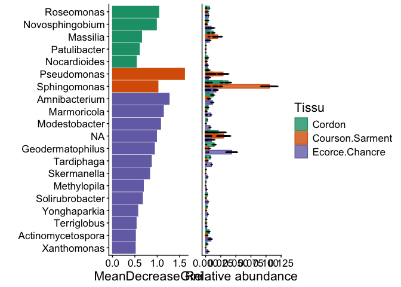

```r
# Random forest feature selection
# Tissue discriminate taxa
# use Genus level for parameter taxa_level, if you want to use all taxa, change to "all"
# nresam = 1 and boots = 1 represent no bootstrapping and use all samples directly
#bacteria
bact.diff.rf <- trans_diff$new(dataset = MBV16S_mt, method = "rf", group = "Tissu", taxa_level = "Genus")
# plot the MeanDecreaseGini bar
# group_order is designed to sort the groups
g1b <- bact.diff.rf$plot_diff_bar(use_number = 1:20, group_order = NULL)+
  theme_classic() +
  theme(text = element_text(size = 16))
# plot the abundance using same taxa in g1
g2b <- bact.diff.rf$plot_diff_abund(group_order = NULL, select_taxa = bact.diff.rf$plot_diff_bar_taxa, plot_type = "barerrorbar", add_sig = FALSE, errorbar_addpoint = FALSE, errorbar_color_black = TRUE)+
  theme_classic() +
  theme(text = element_text(size = 16))
# now the y axis in g1 and g2 is same, so we can merge them
# remove g1 legend; remove g2 y axis text and ticks
g1b <- g1b + theme(legend.position = "none")
g2b <- g2b + theme(axis.text.y = element_blank(), axis.ticks.y = element_blank(), panel.border = element_blank())
pb <- g1b %>% aplot::insert_right(g2b)
pb
```

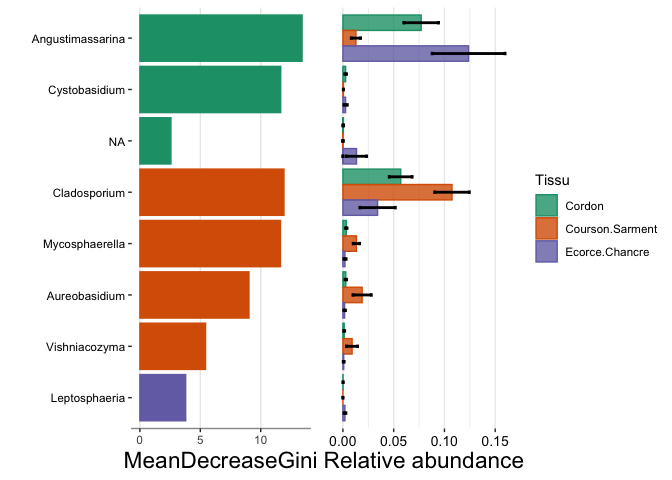

```r
#fungi
fungi.diff.rf <- trans_diff$new(dataset = MBVITS_mt, method = "rf", group = "Tissu", taxa_level = "Genus")
# plot the MeanDecreaseGres_diff# plot the MeanDecreaseGini bar
# group_order is designed to sort the groups
g1f <- fungi.diff.rf$plot_diff_bar(use_number = 1:20, group_order = NULL)
# plot the abundance using same taxa in g1
g2f <- fungi.diff.rf$plot_diff_abund(group_order = NULL, select_taxa = fungi.diff.rf$plot_diff_bar_taxa, plot_type = "barerrorbar", add_sig = FALSE, errorbar_addpoint = FALSE, errorbar_color_black = TRUE)
# now the y axis in g1 and g2 is same, so we can merge them
# remove g1 legend; remove g2 y axis text and ticks
g1f <- g1f + theme(legend.position = "none")
g2f <- g2f + theme(axis.text.y = element_blank(), axis.ticks.y = element_blank(), panel.border = element_blank())
pf <- g1f %>% aplot::insert_right(g2f)
pf
```

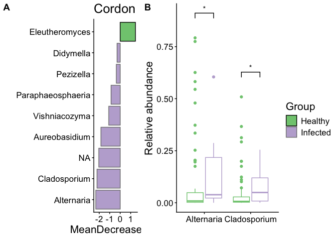

```r
bacterial_res_rf <- list()
#filtering by tissue to identify differential taxa on infected vs healthy plants
tissues <- c("Cordon", "Courson.Sarment", "Ecorce.Chancre")

for (tissue in tissues) {
  # Filter sample table
  sub_microt <-clone(MBV16S_mt)
  sub_microt$sample_table <- subset(sub_microt$sample_table, Tissu == tissue)
  sub_microt$tidy_dataset()
  bacterial_res_rf[[tissue]] <-  trans_diff$new(dataset = sub_microt, method = "rf", group = "Infected", taxa_level = "Genus", p_adjust_method = "none")
}

fungal_res_rf <- list()
#filtering by tissue to identify differential taxa on infected vs healthy plants
for (tissue in tissues) {

  # Filter sample table
  sub_microt <-clone(MBVITS_mt)
  sub_microt$sample_table <- subset(sub_microt$sample_table, Tissu == tissue)
  sub_microt$tidy_dataset()
  #fungal_res_rf[[tissue]] <-  trans_diff$new(dataset = sub_microt, method = "metagenomeSeq", group = "Infected", taxa_level = "Family", p_adjust_method = "none")
  fungal_res_rf[[tissue]] <-  trans_diff$new(dataset = sub_microt, method = "rf", group = "Infected", taxa_level = "Genus", p_adjust_method = "none")
}

# plot fungal features descriminating healthy and symptomatic vines in Cordon tissue
ggarrange(fungal_res_rf$Cordon$plot_diff_bar(color_values = "black")+
            labs(title = "Cordon") +
            #theme(legend.position = "none")+
    scale_fill_brewer(palette = "Accent") +
    theme_classic() +
    theme(text = element_text(size = 16)), fungal_res_rf$Cordon$plot_diff_abund(coord_flip = F, use_number = c(1:2), group_order = NULL)+
    scale_color_brewer(palette = "Accent") +
    theme_classic() +
    theme(text = element_text(size = 16)), ncol = 2, labels = c("A", "B"), common.legend = TRUE, legend = "right")
```

### Dysbiosis measure

**Random Forest Prediction Based Score using the dysbiosisOBB function**

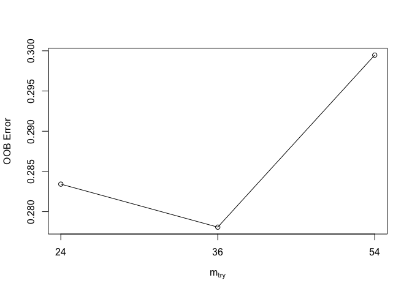

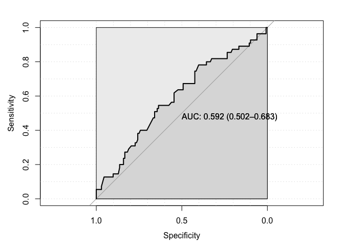

```r
# Dysbiosis index
# This analysis ask the question : how far does a sample fall from the references samples "healthy" microbial neighborhood?

# Dysbiosis R package
#it uses a phyloseq object so we need to transform

tax_matbact <- as.matrix(MBV16S_mt$tax_table [,c(2:7)])
MBV16S_ps = phyloseq(otu_table(MBV16S_mt$otu_table, taxa_are_rows = TRUE), tax_table(tax_matbact), sample_data(MBV16S_mt$sample_table))


tax_mat <- as.matrix(MBVITS_mt$tax_table [,c(2:7)])
MBVITS_ps = phyloseq(otu_table(MBVITS_mt$otu_table, taxa_are_rows = TRUE), tax_table(tax_mat), sample_data(MBVITS_mt$sample_table))
subset_samples(MBVITS_ps, Tissu =="Cordon")

#transform data
totalb = median(sample_sums(MBV16S_ps))
totalf = median(sample_sums(MBVITS_ps))
standfb = function(x, t=totalb) round(t * (x / sum(x)))
standff = function(x, t=totalf) round(t * (x / sum(x)))
MBV16S_ps_ra = transform_sample_counts(MBV16S_ps, standfb)
MBVITS_ps_ra = transform_sample_counts(MBVITS_ps, standff)
#sampling sizes
#table(sample_data(MBV16S_ps_ra)$Infected)
#table(sample_data(MBVITS_ps_ra)$Infected)


###
#
#Dysbiosis measures
# Compare area under the curve
# use one dataset and then save in a list at the end of the script for all indexes
# REMEMBER change the phyloseq object to select eihter bacteria or fungal dataset
##
dist.mat <- phyloseq::distance(MBV16S_ps_ra, "bray")
# get reference samples
ref.samples <- sample_names(subset_samples(MBV16S_ps_ra,
                                           Infected == "Healthy"))
# random forest prediction based score

# data are relative abundances summed to 100 or
# near 100 val
dysbiosis.oob <- dysbiosisOBB(MBV16S_ps_ra,
                              group_col = "Infected",
                              case_label = "Infected",
                              seed_value = 1235,
                              add_tuneRF_params = list(ntreeTry=100,
                                                       stepFactor=1.5,
                                                       improve=0.01,
                                                       trace=TRUE,
                                                       dobest=FALSE),
                              ntree = 100,
                              plot_roc = TRUE)
```

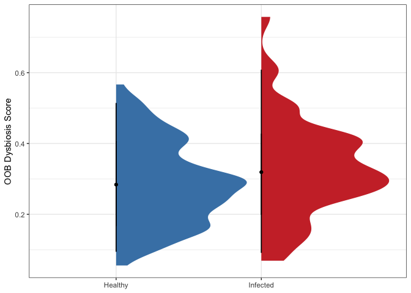

```r
p5 <- plotDysbiosis(df=dysbiosis.oob,
                    xvar="Infected",
                    yvar="oob.score",
                    colors=c(Infected="brown3", Healthy="steelblue"),
                    show_points = FALSE)+
  labs(x="", y="OOB Dysbiosis Score")
p5
```